# Pipes in R

February 01, 2017

## Example

```r
#Before Using Pipes
subsets <- split(D, D$V1)

SV2_1 <- split(subsets[[1]], subsets[[1]]$V2)
NM_1 <- JS.uni(SV2_1[[1]], 'scensor','surv', 'g65' ,'T1 and NM1')
NM_2 <- JS.uni(SV2_1[[2]], 'scensor','surv', 'g65' ,'T2 and NM1')
NM_3 <- JS.uni(SV2_1[[3]], 'scensor','surv', 'g65' ,'T3 and NM1')

SV2_2 <- split(subsets[[2]], subsets[[2]]$V2)
M_1 <- JS.uni(SV2_2[[1]], 'scensor','surv', 'g65' ,'T1 and NM2')
M_2 <- JS.uni(SV2_2[[2]], 'scensor','surv', 'g65' ,'T2 and NM2')
M_3 <- JS.uni(SV2_2[[3]], 'scensor','surv', 'g65' ,'T3 and NM2')

model <- rbind(NM_1, NM_2, NM_3, M_1, M_2, M_3)
```

## Example

```r
#After Using Pipes
model <- D %>%
           filter(.$V2 %in% c(0,1), complete.cases(.$V1)) %>%
           split(list(.$v2, .$v1)) %>%
           map(~JS.uni(D = .,'scensor','surv', 'g65','T and M' ))%>%
           do.call(rbind,.)
```

1 object, 5 lines of code

## Introduction

- The %>% operatior
- Other tools from **'magrittr'** (%$%, %T>% and %<>%)
- When not to use the pipe operator
- Core packages of **'tidyverse'**

## The %>% operatior

- Comes from the 'magrittr' package and introduced to 'dplyr' package

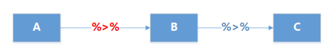

- x %>% f== f(x)
- x %>% f(arg=value) == f(x, arg=value)

```r
mean(iris$Sepal.Length)
```

```r
iris$Sepal.Length %>% mean
```

```
## [1] 5.843333
```

## The %>% operatior

- What if the object is not the first agreement ?
- . (dot)
- y %>% f(x, .) == f(x, y)
- z %>% f(x, y, arg = .) is equivalent to f(x, y, arg = z)

```r
#Before
summary(lm(Sepal.Length ~ Sepal.Width, data = iris))
```

```r
#After
iris %>%
     lm(Sepal.Length ~ Sepal.Width, data = .)  %>%
     summary
```

## The %>% operatior (check data)

```r
iris %>%
  mutate(Sepal.Size=Sepal.Length*Sepal.Width,
         Petal.Size=Petal.Length*Petal.Width) %>% # (head(5))
  select(Sepal.Size,Petal.Size,Species) %>%
  group_by(Species) %>%
  do(arrange(.,desc(Sepal.Size+Petal.Size)) %>% head(3))
```

```
## Source: local data frame [9 x 3]
## Groups: Species [3]
##
##   Sepal.Size Petal.Size    Species
##        <dbl>      <dbl>     <fctr>
## 1      25.08       0.60     setosa
## 2      23.20       0.24     setosa
## 3      23.10       0.28     setosa
## 4      22.40       6.58 versicolor
## 5      21.39       7.35 versicolor
## 6      20.10       8.50 versicolor
## 7      29.26      14.74  virginica
## 8      30.02      12.80  virginica
## 9      25.92      15.25  virginica
```

## The %T% operatior

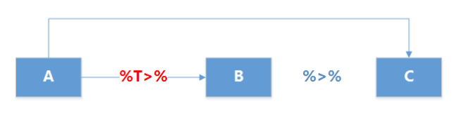

- when use print(), plot(), save ()…
- Returns the left-hand side instead of the right-hand side.

## The %T% operatior (Example)

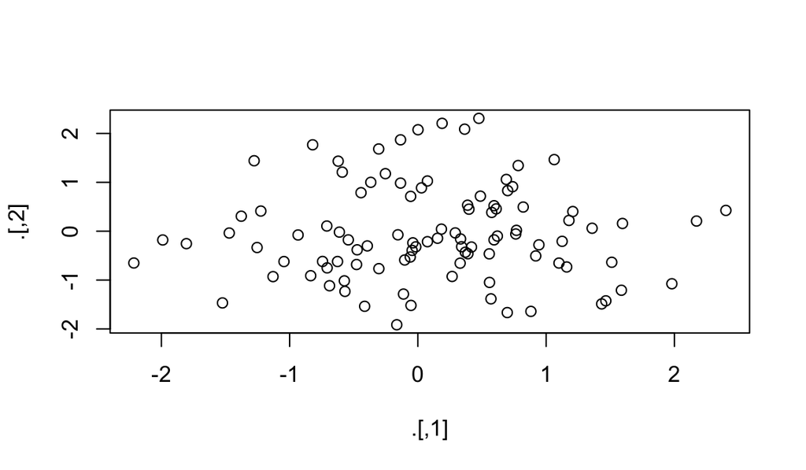

```r
set.seed(1)
 rnorm(200) %>% matrix(ncol = 2) %>%
   plot %>% str
```

## The %T% operatior (Example)

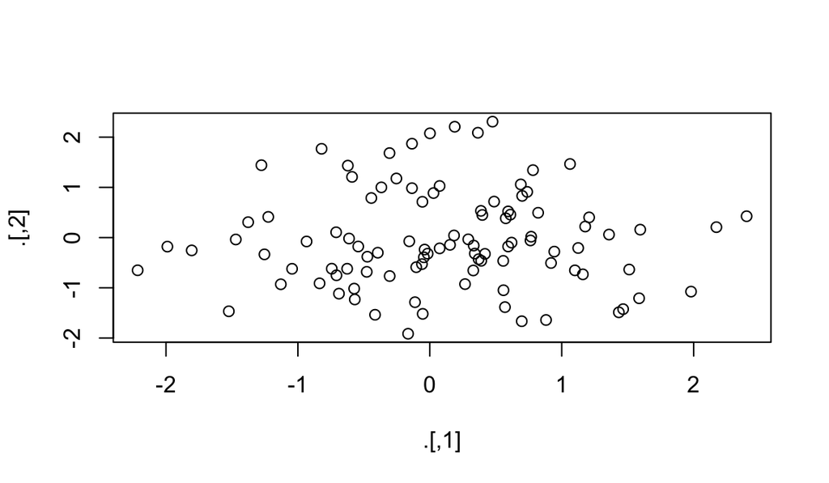

```
##  num [1:100, 1:2] -0.626 0.184 -0.836 1.595 0.33 ...
```

```r
set.seed(1)
rnorm(200) %>% matrix(ncol = 2) %T>%
   plot %>% str
```

## The %$% operatior

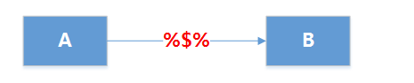

- Working with functions that don't have a data frame based API
- Base R funcation , for example, mean(), cor() …
- Explodes out the variables in a data frame

## The %$% operatior (Example)

```r
iris %>%
     lm(Sepal.Length ~ Sepal.Width, data = .)
```

```r
iris %$%
     lm(Sepal.Length ~ Sepal.Width)
```

```
##
## Call:
## lm(formula = Sepal.Length ~ Sepal.Width)
##
## Coefficients:
## (Intercept)  Sepal.Width
##      6.5262      -0.2234
```

## The %<>% operatior

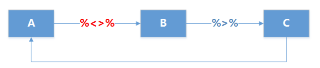

- Replace your objects
- usage

```r
 iris$Sepal.Length %<>% sqrt
```

- replacement of

```r
 iris$Sepal.Length <- iris$Sepal.Length %>% sqrt
```

## When not to Use the Pipe Operators

- Multiple inputs or outputs
  - check PipeR package
- Longer steps
- Functions that use the current environment
  - assign()
  - get()
  - load()
- Functions that use lazy evaluation
  - tryCatch()
  - try()

## tidyverse package

- The tidyverse is a suite of tools to make managing data easier in to your R session
- Install and load packages from the tidyverse in a single command.
- Usage

```r
library(tidyverse)
tidyverse_conflicts() #see conflicts
tidyverse_update()    #check if all tidyverse packages are up-to-date
```

## tidyverse package (core packages)

- **ggplot2** : data visualisation.
- **dplyr** : data manipulation.
- **tidyr** : data tidying.
- **readr** : data import.
- **purrr** : functional programming.
- **tibble** : manipulating and printing data frames in R..

## tidyverse package(Other packages)

- **Data import**
  - DBI, for databases.
  - haven, for SPSS, SAS and Stata files.
  - httr, for web apis.
  - jsonlite , for JSON.
  - readxl, for .xls and .xlsx files.
  - rvest, for web scraping.
  - xml2, for XML.

## tidyverse package(Other packages)

- **Data manipulation**
  - hms, for times.
  - stringr, for strings.
  - lubridate, for date/times.
  - forcats, for factors.
- **Modelling**
  - modelr, for simple modelling within a pipeline
  - broom, for turning models into tidy data

## Data Tidying (tidyr)

- Transforming data into a clear and simple form that makes it easy to work with
- Easy to work with dplyr
- Main tools
  - **gather()** : converts wide data to longer format (reshape2::melt)
  - **spread()** : converts long data to wider format (reshape2::cast)
  - **separate()** : tease apart variables that clumped together in one column
  - **drop_na()** : drops rows containing missing values
  - **complete()** : turn implicit missing values into explicit missing values.

## Data Import(readr)

- Faster
- Main tools
  - **Delimited files** : read_delim(), read_csv(), read_tsv(), read_csv2()
  - **Fixed width files** : d_fwf(), and read_table()
  - **Web log files** :read_log()
- Other data import package in tidyverse
  - readxl for excel;
  - haven for SAS, SPSS and Stata + problem

## Functional Programming (purrr)

- **map()**

```r
# example
mtcars %>%
  split(.$cyl) %>%
  map(~lm(mpg ~ wt, data = .)) %>%
  map(summary) %>%
  map_dbl("r.squared")
```

```
##         4         6         8
## 0.5086326 0.4645102 0.4229655
```

## Functional Programming (purrr)

- **map()** return a list
- **map_lgl()**, **map_chr()**, **map_dbl()**, and **map_int()** return an atomic vector
- **map_if()** only applies .f to those elements of the list where .p is true.

```r
#.p == is.factor  ;   #.f == as.character ;
iris  %>% map_if(is.factor, as.character) %>% str()
```

```
## List of 5
##  $ Sepal.Length: num [1:150] 2.26 2.21 2.17 2.14 2.24 ...
##  $ Sepal.Width : num [1:150] 3.5 3 3.2 3.1 3.6 3.9 3.4 3.4 2.9 3.1 ...
##  $ Petal.Length: num [1:150] 1.4 1.4 1.3 1.5 1.4 1.7 1.4 1.5 1.4 1.5 ...
##  $ Petal.Width : num [1:150] 0.2 0.2 0.2 0.2 0.2 0.4 0.3 0.2 0.2 0.1 ...
##  $ Species     : chr [1:150] "setosa" "setosa" "setosa" "setosa" ...
```

## Example

```r
#After Using Pipe
model <- D %>%
           filter(.$V2 %in% c(0,1), complete.cases(.$V1)) %>%
           split(list(.$v2, .$v1)) %>%
           map(~JS.uni(D = .,'scensor','surv', 'g65','T and M' ))%>%
           do.call(rbind,.)
```

### Contact

- Sophia Jia
- jiax@ccf.org